# Question

A right triangle with an acute angle of $\frac{\pi}{6}$ has short-leg length of 3.95 meters.

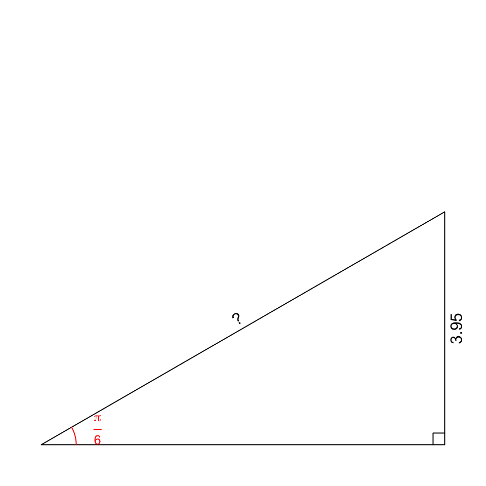

Find the hypotenuse length in meters. The tolerance is $\pm0.01$ meters.

# Solution

You should be able to derive the side-length ratios of $\frac{\pi}{4}$-$\frac{\pi}{4}$-$\frac{\pi}{2}$ triangles and $\frac{\pi}{6}$-$\frac{\pi}{3}$-$\frac{\pi}{2}$ triangles by using Pythagorean Theorem.

### Ratios of $\frac{\pi}{4}$-$\frac{\pi}{4}$-$\frac{\pi}{2}$ triangles

$\frac{\pi}{4}$-$\frac{\pi}{4}$-$\frac{\pi}{2}$ triangle’s ratios are easy to derive. Because it is [isosceles](https://en.wikipedia.org/wiki/Isosceles_triangle), both legs are congruent. We can use $x$ to represent the length of a leg and $c$ to represent the length of the hypotenuse.

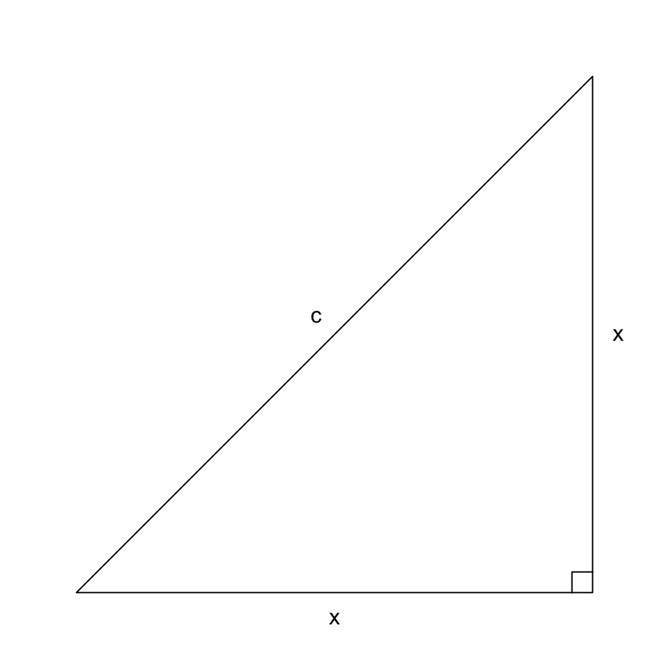

If we use Pythagorean Theorem:

$$x^2+x^2 = c^2$$
Combine similar terms.

$$2x^2 = c^2$$

Take the square root of both sides.

$$\sqrt{2x^2} = \sqrt{c^2}$$

Simplify.

$$\frac{c}{x} = \sqrt{2}$$

Any of the triangles below indicate the ratios of a $\frac{\pi}{4}$-$\frac{\pi}{4}$-$\frac{\pi}{2}$ triangle.

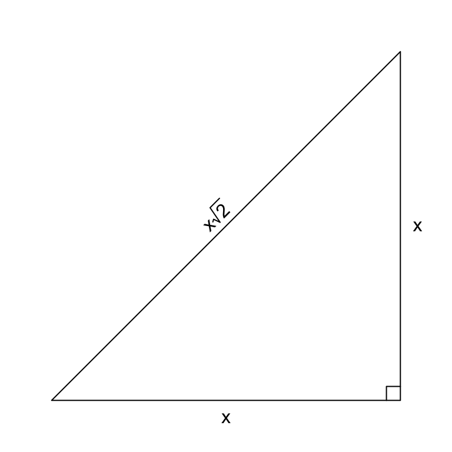

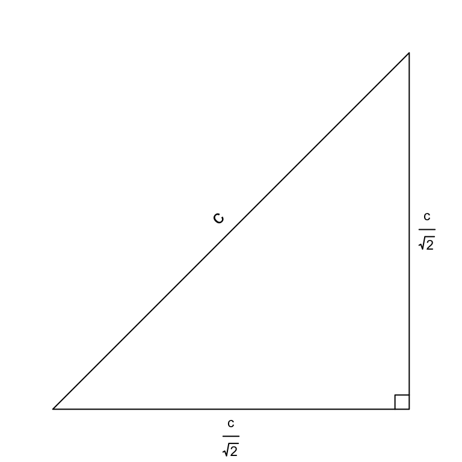

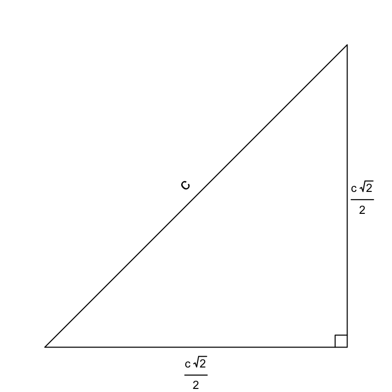

The 3-part ratios can be expressed in various ways.

$$1:1:\sqrt{2}$$

$$\frac{1}{\sqrt{2}} : \frac{1}{\sqrt{2}}
: 1$$

$$\frac{\sqrt{2}}{2} : \frac{\sqrt{2}}{2}
: 1$$

### The $\frac{\pi}{6}$-$\frac{\pi}{3}$-$\frac{\pi}{2}$ triangle ratios

The ratios of a $\frac{\pi}{6}$-$\frac{\pi}{3}$-$\frac{\pi}{2}$ triangle are also straight-forward to prove. Begin by drawing an equilateral triangle. Cut the equilateral triangle in half. That half of the equilateral triangle will be a $\frac{\pi}{6}$-$\frac{\pi}{3}$-$\frac{\pi}{2}$ triangle. In that $\frac{\pi}{6}$-$\frac{\pi}{3}$-$\frac{\pi}{2}$ triangle, the short leg is half as long as the hypotenuse.

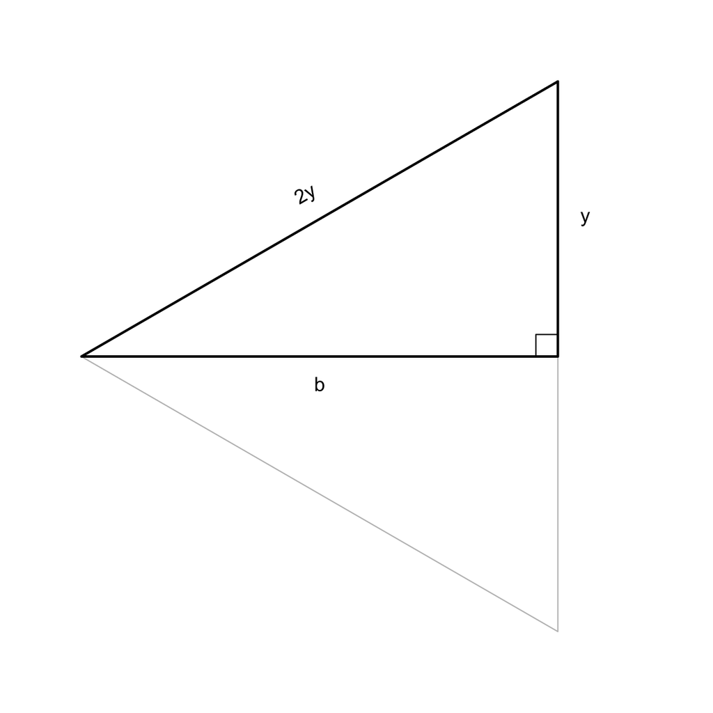

Use Pythagorean Theorem:

$$y^2+b^2 = (2y)^2$$

An exponent can distribute over multiplication.

$$y^2+b^2 = 4y^2$$

Subtract $y^2$ from both sides.
$$b^2 = 3y^2$$
Square root both sides.

$$b = y\sqrt{3}$$

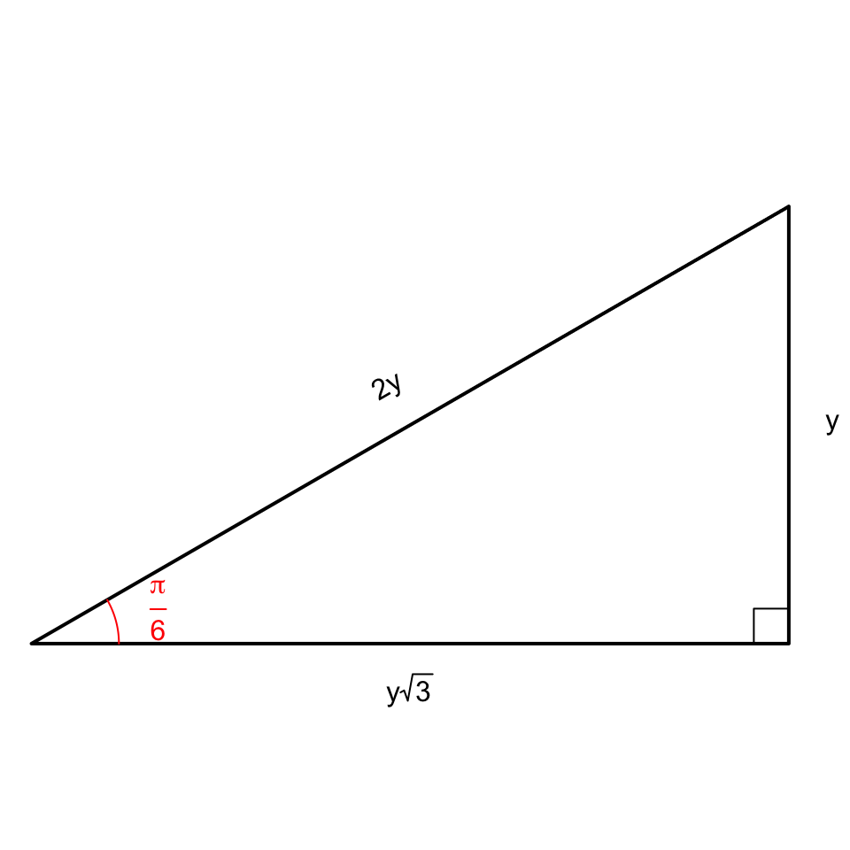

The 3-part ratios can be expressed in various ways.

$$1:\sqrt{3}:2$$
$$\frac{\sqrt{3}}{3} : 1 :
\frac{2\sqrt{3}}{3}$$

$$\frac{1}{2} : \frac{\sqrt{3}}{2} :
1$$

### This specific problem

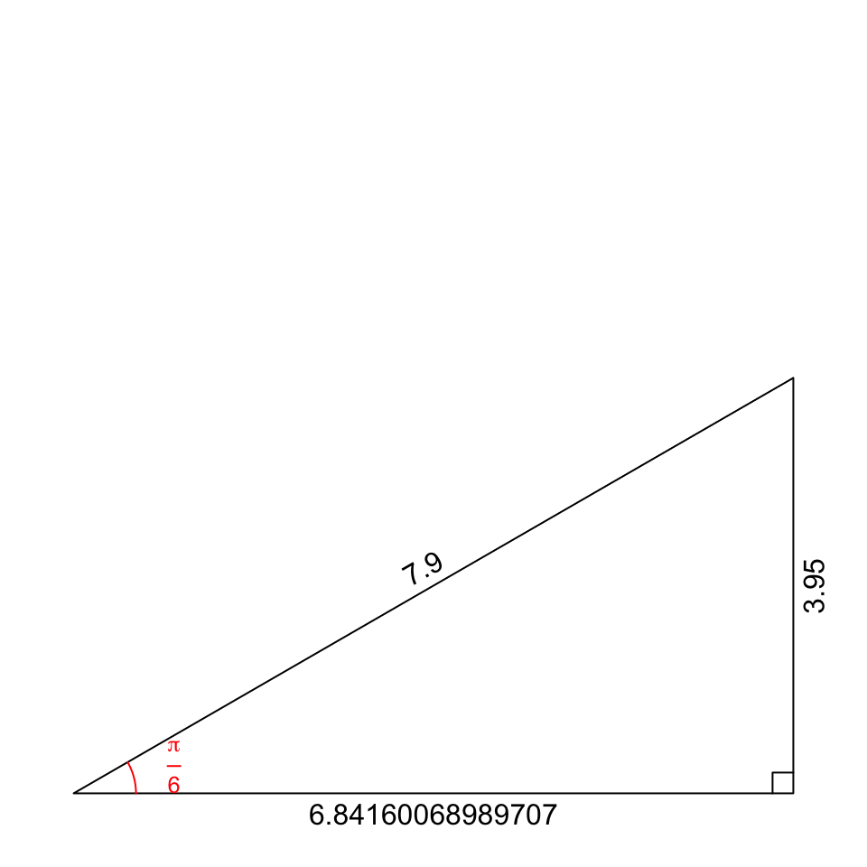

So, the answer is approximately 7.9 meters.

# Meta-information

extype: num exsolution: 7.9 exname: srt extol: 0.01